# stepik_report_5

Alona Sychevska

10/25/2019

```r
library(psych)
library(ggplot2)
library(GGally)
library(qqplotr)
library(lattice)
library(Rmisc)
library(Hmisc)
```

# Загрузка данных

```r
diabetes <- read.csv("~/code/scripts/R/stepik_projects/diabetes.csv")
```

#Определите тип каждого признака (количественные, порядковые, качественные).

```r
diabetes$Outcome <- factor(diabetes$Outcome)
levels(diabetes$Outcome) <- c("Здоров", "Болен")
```

# Работа с NA

```r
diabetes$BloodPressure[diabetes$BloodPressure == "0"] <- NA
diabetes$Glucose[diabetes$Glucose == "0"] <- NA
diabetes$SkinThickness[diabetes$SkinThickness == "0"] <- NA
diabetes$Insulin[diabetes$Insulin == '0'] <- NA
diabetes$BMI[diabetes$BMI == '0'] <- NA
diabetes$DiabetesPedigreeFunction[diabetes$DiabetesPedigreeFunction == '0'] <- NA

colSums(is.na(diabetes))
```

```
##              Pregnancies                  Glucose            BloodPressure
##                        0                        5                       35
##            SkinThickness                  Insulin                      BMI
##                      227                      374                       11
## DiabetesPedigreeFunction                      Age                  Outcome
##                        0                        0                        0
```

```r
diabetes <- na.omit(diabetes)
```

1. Для всех количественных признаков проверьте гипотезу о том, что они распределены нормально. Запишите свои наблюдения

Для проверки распределения на нормальность используется Shapiro-Wilk normality test или же Mann_Whitney U-test, если есть outliers. H0 – нулевая гипотеза, что наше распределение значимо не отличается от нормального и если мы получаем p-value > 0,05 – это хорошо в нашем случае. H1 – альтернативная гипотеза о том, что наше распределение отличается от нормального.

В результате я получила очень низкие p-value, то есть нужно отклонить нулевую гипотезу.

```r
#m <- names(diabetes)[sapply(diabetes, is.numeric)]
#sapply(diabetes[, m], shapiro.test)

shapiro.test(diabetes$Pregnancies)
```

```
##
##  Shapiro-Wilk normality test
##
## data:  diabetes$Pregnancies
## W = 0.85295, p-value < 2.2e-16
```

```r
shapiro.test(diabetes$Glucose)
```

```
##
##  Shapiro-Wilk normality test
##
## data:  diabetes$Glucose
## W = 0.96423, p-value = 3.442e-08
```

```r
shapiro.test(diabetes$BloodPressure)
```

```
##
##  Shapiro-Wilk normality test
##
## data:  diabetes$BloodPressure
## W = 0.98994, p-value = 0.008712
```

```r
shapiro.test(diabetes$SkinThickness)
```

```
##
##  Shapiro-Wilk normality test
##
## data:  diabetes$SkinThickness
## W = 0.98758, p-value = 0.001991
```

```r
shapiro.test(diabetes$Insulin)
```

```
##
##  Shapiro-Wilk normality test
##
## data:  diabetes$Insulin
## W = 0.80401, p-value < 2.2e-16
```

```r
shapiro.test(diabetes$BMI)
```

```
##
##  Shapiro-Wilk normality test
##
## data:  diabetes$BMI
## W = 0.97384, p-value = 1.657e-06
```

```r
shapiro.test(diabetes$DiabetesPedigreeFunction)
```

```
##
##  Shapiro-Wilk normality test
##
## data:  diabetes$DiabetesPedigreeFunction
## W = 0.84858, p-value < 2.2e-16
```

```r
shapiro.test(diabetes$Age)
```

```
##
##  Shapiro-Wilk normality test
##
## data:  diabetes$Age
## W = 0.8383, p-value < 2.2e-16
```

2. Для всех количественных признаков проверьте гипотезу о том, различается ли среднее между здоровыми и больными людьми. Напишите, как вы выбрали между парным и непарным t-test и почему в этой ситуации вообще корректно использовать t-test. Запишите свои наблюдения

Я выбрала непарный t-test, так как у нас переменные независимы. Можно увидеть, что среднее значения по всех переменных в больных людей выше, чем в здоровых, но больше всего это заметно по переменной Insulin.

```r
t.test(Pregnancies~Outcome, diabetes)
```

```
##
##  Welch Two Sample t-test
##
## data:  Pregnancies by Outcome
## t = -4.604, df = 187.98, p-value = 7.618e-06
## alternative hypothesis: true difference in means is not equal to 0
## 95 percent confidence interval:
##  -2.4967630 -0.9989505
## sample estimates:
## mean in group Здоров  mean in group Болен
##             2.721374             4.469231
```

```r
t.test(Glucose~Outcome, diabetes)
```

```
##
##  Welch Two Sample t-test
##
## data:  Glucose by Outcome
## t = -11.151, df = 218.7, p-value < 2.2e-16
## alternative hypothesis: true difference in means is not equal to 0
## 95 percent confidence interval:
##  -39.72817 -27.79385
## sample estimates:
## mean in group Здоров  mean in group Болен
##             111.4313             145.1923
```

```r
t.test(BloodPressure~Outcome, diabetes)
```

```
##
##  Welch Two Sample t-test
##
## data:  BloodPressure by Outcome
## t = -3.761, df = 237.75, p-value = 0.0002131
## alternative hypothesis: true difference in means is not equal to 0
## 95 percent confidence interval:
##  -7.782699 -2.432216
## sample estimates:
## mean in group Здоров  mean in group Болен
##             68.96947             74.07692
```

```r
t.test(SkinThickness~Outcome, diabetes)
```

```
##
##  Welch Two Sample t-test
##
## data:  SkinThickness by Outcome
## t = -5.3693, df = 276.33, p-value = 1.677e-07
## alternative hypothesis: true difference in means is not equal to 0
## 95 percent confidence interval:
##  -7.802999 -3.616261
## sample estimates:
## mean in group Здоров  mean in group Болен
##             27.25191             32.96154
```

```r
t.test(Insulin~Outcome, diabetes)
```

```
##
##  Welch Two Sample t-test
##
## data:  Insulin by Outcome
## t = -5.7337, df = 207.88, p-value = 3.429e-08
## alternative hypothesis: true difference in means is not equal to 0
## 95 percent confidence interval:
##  -102.11966  -49.86272
## sample estimates:
## mean in group Здоров  mean in group Болен
##             130.8550             206.8462
```

```r
t.test(BMI~Outcome, diabetes)
```

```
##
##  Welch Two Sample t-test
##
## data:  BMI by Outcome
## t = -5.5571, df = 259.51, p-value = 6.797e-08
## alternative hypothesis: true difference in means is not equal to 0
## 95 percent confidence interval:
##  -5.453875 -2.599983
## sample estimates:
## mean in group Здоров  mean in group Болен
##             31.75076             35.77769
```

```r
t.test(DiabetesPedigreeFunction~Outcome, diabetes)
```

```
##
##  Welch Two Sample t-test
##
## data:  DiabetesPedigreeFunction by Outcome
## t = -3.8245, df = 200.74, p-value = 0.0001749
## alternative hypothesis: true difference in means is not equal to 0
## 95 percent confidence interval:
##  -0.23251667 -0.07431668
## sample estimates:
## mean in group Здоров  mean in group Болен
##            0.4721679            0.6255846
```

```r
t.test(Age~Outcome, diabetes)
```

```
##
##  Welch Two Sample t-test
##
## data:  Age by Outcome
## t = -6.993, df = 222.83, p-value = 3.098e-11
## alternative hypothesis: true difference in means is not equal to 0
## 95 percent confidence interval:
##  -9.730358 -5.451909
## sample estimates:
## mean in group Здоров  mean in group Болен
##             28.34733             35.93846
```

3. Для всех количественных признаков постройте 95% доверительные интервалы для среднего по группам болен-здоров.

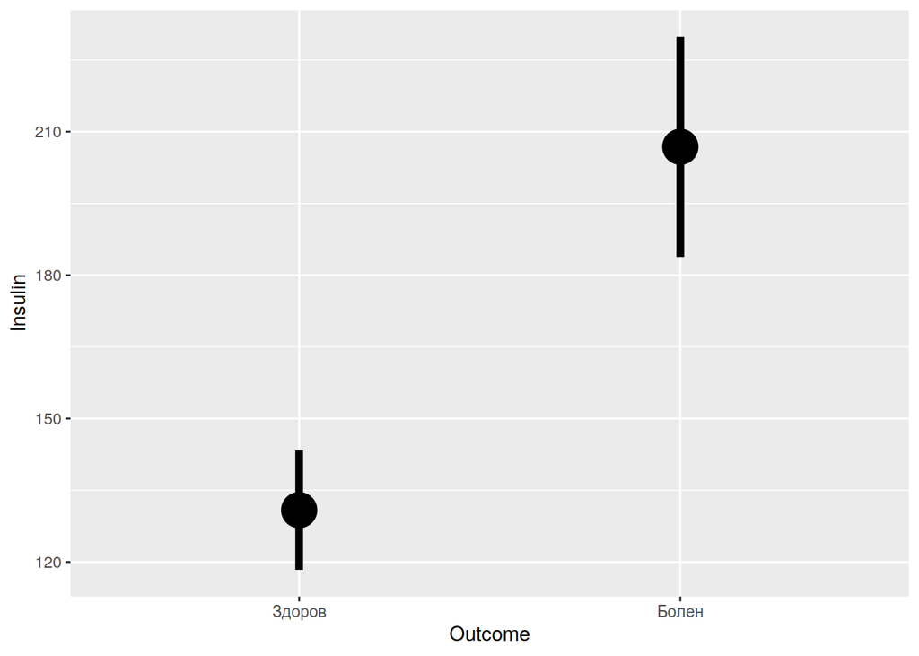

```r
ggplot(diabetes, aes(Outcome, Insulin)) +
  stat_summary(fun.data = mean_cl_normal,
  geom = "pointrange", size=2)
```

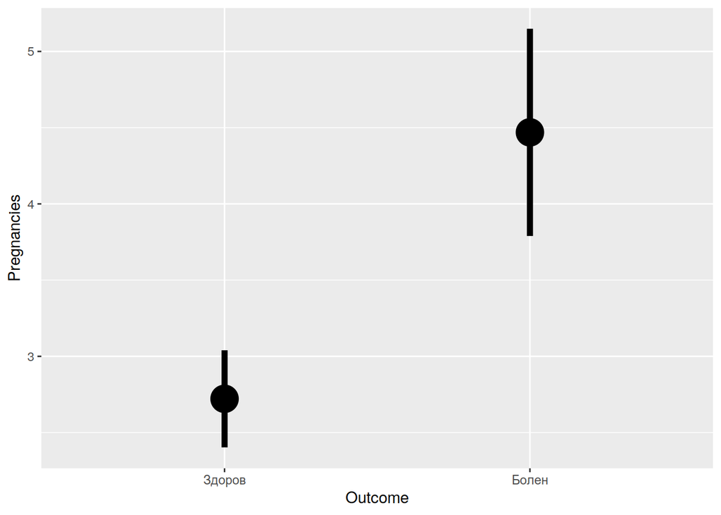

```r
ggplot(diabetes, aes(Outcome, Pregnancies)) +
  stat_summary(fun.data = mean_cl_normal,
  geom = "pointrange", size=2)
```

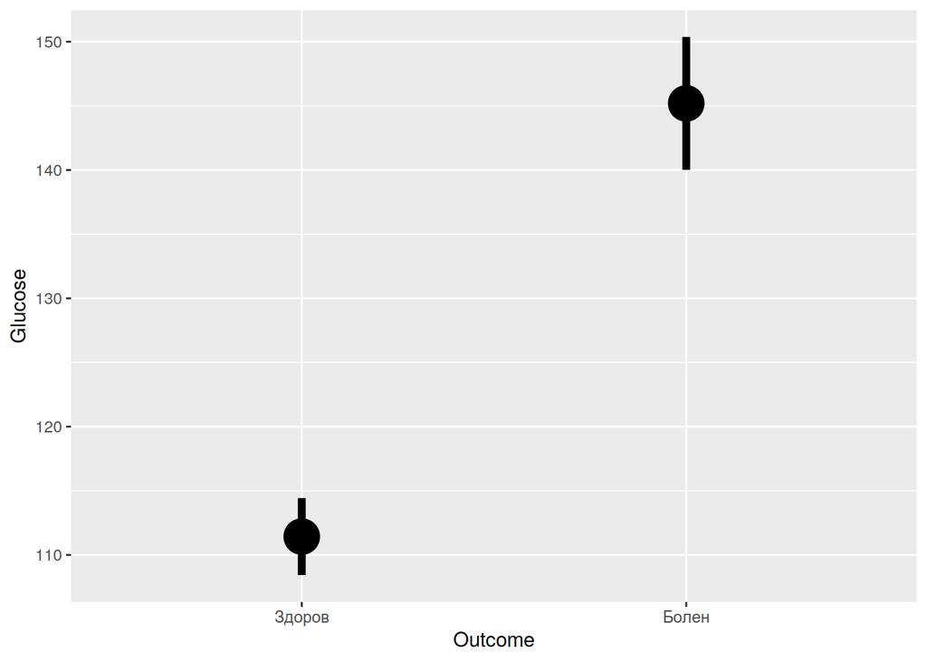

```r
ggplot(diabetes, aes(Outcome, Glucose)) +
  stat_summary(fun.data = mean_cl_normal,
  geom = "pointrange", size=2)
```

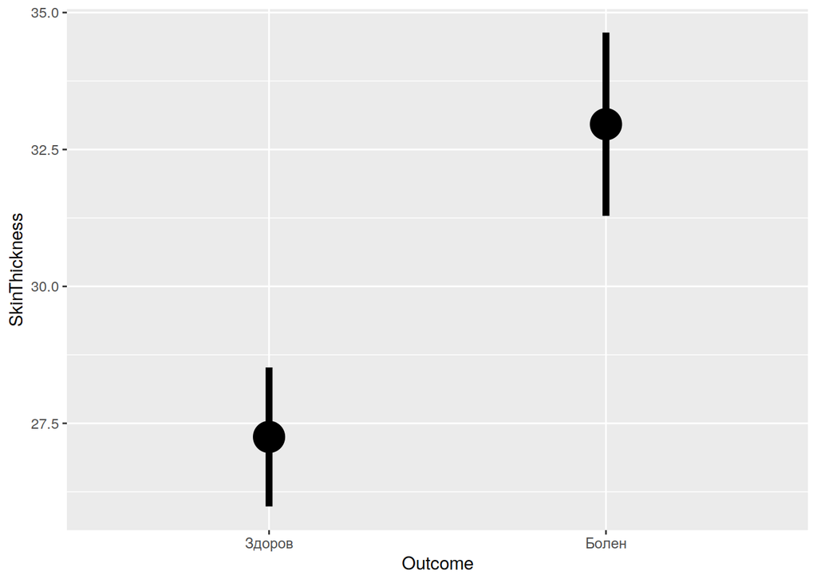

```r
ggplot(diabetes, aes(Outcome, SkinThickness)) +
  stat_summary(fun.data = mean_cl_normal,
  geom = "pointrange", size=2)
```

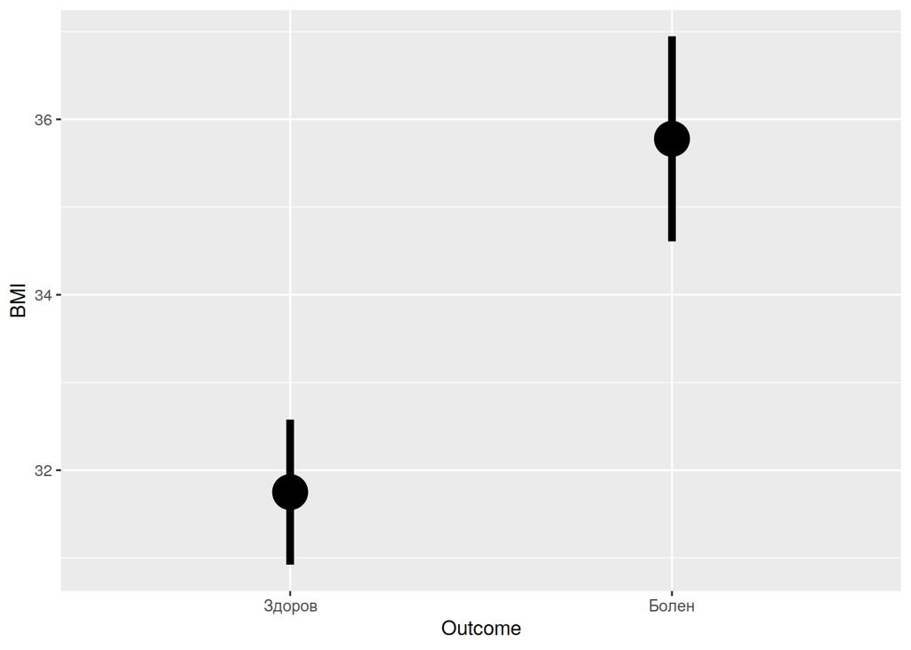

```r
ggplot(diabetes, aes(Outcome, BMI)) +
  stat_summary(fun.data = mean_cl_normal,
  geom = "pointrange", size=2)
```

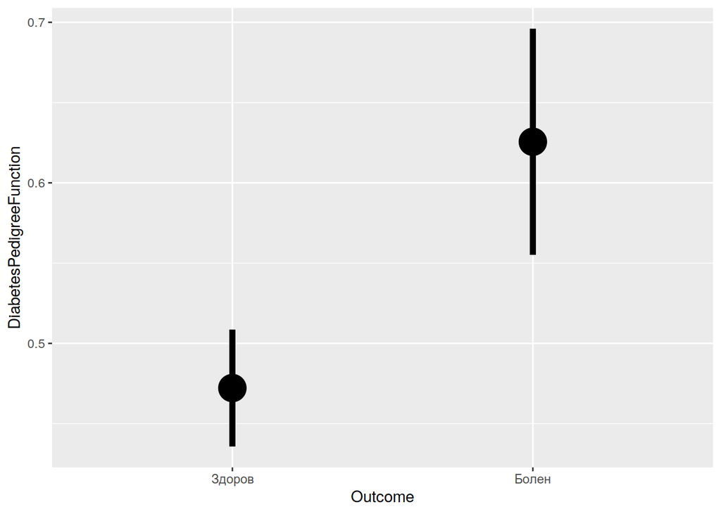

```r
ggplot(diabetes, aes(Outcome, DiabetesPedigreeFunction)) +
  stat_summary(fun.data = mean_cl_normal,
  geom = "pointrange", size=2)
```

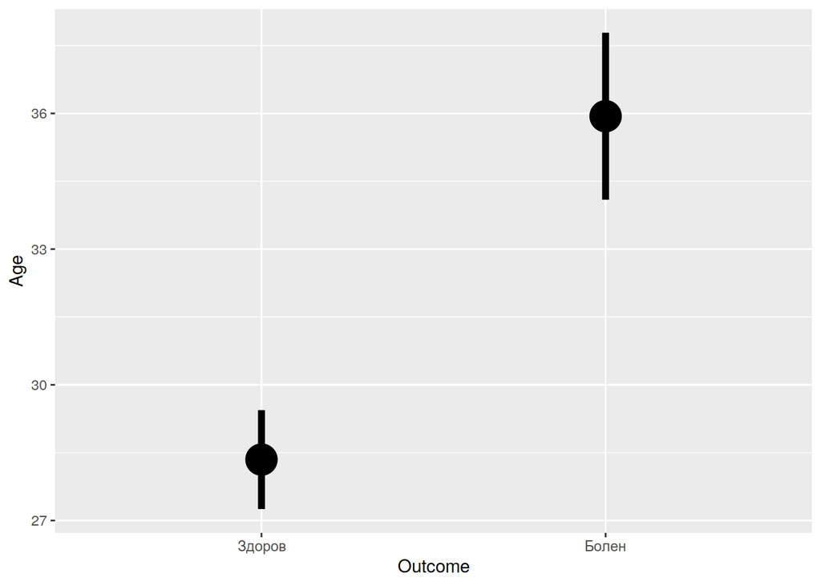

```r
ggplot(diabetes, aes(Outcome, Age)) +
  stat_summary(fun.data = mean_cl_normal,
  geom = "pointrange", size=2)
```

4. Как мы знаем, если интервалы не пересекаются (а если точнее, если одно среднее не лежит в ди для другого среднего и наоборот), то отличие между этими среднее важное. Посмотрите на признаки, которые различаются с точки зрения ди и с точки зрения t-test, совпадают ли эти признаки?
5. Для всех пар количественных переменных сделайте тест на значимость корреляции. Запишите свои наблюдения